# Lab #3

WEI-XUAN HU

2024-02-05

## 0. Download packages

```r
# Download the package

install.packages("dplyr")
```

```r
install.packages("ggplot2")
library("dplyr")
library("ggplot2")
```

## 1.Data Preparation

```r
# Import Data (FoodAtlas.csv)
food_data <- read.csv("FoodAtlas.csv")

# show only the first 24
# head(food_data, 24)

# show only last 12 variables
# tail(food_data,12)

# For keep only the first 24 and last 12 variables.

selected_variables <- c(colnames(food_data)[1:24], colnames(food_data)[(length(colnames(food_data)) - 11):length(colnames(food_data))])

# reduced dataset is named as reduces_data
reduced_data <- food_data[, selected_variables]

# show the data
head(reduced_data)
```

```
##   CensusTract   State  County Urban POP2010 OHU2010 GroupQuartersFlag NUMGQTRS
## 1  1001020100 Alabama Autauga     1    1912     693                 0        0
## 2  1001020200 Alabama Autauga     1    2170     743                 0      181
## 3  1001020300 Alabama Autauga     1    3373    1256                 0        0
## 4  1001020400 Alabama Autauga     1    4386    1722                 0        0
## 5  1001020500 Alabama Autauga     1   10766    4082                 0      181
## 6  1001020600 Alabama Autauga     1    3668    1311                 0        0
##    PCTGQTRS LILATracts_1And10 LILATracts_halfAnd10 LILATracts_1And20
## 1 0.0000000                 0                    0                 0
## 2 0.0834101                 0                    0                 0
## 3 0.0000000                 0                    0                 0
## 4 0.0000000                 0                    0                 0
## 5 0.0168122                 0                    0                 0
## 6 0.0000000                 0                    0                 0
##   LILATracts_Vehicle HUNVFlag LowIncomeTracts PovertyRate MedianFamilyIncome
```

[output cut: 27 more lines]

## 2.Examine this reduced dataset and decribe their types.

```r
## Food_Data is a Data Frame.
# What's the data type
class(food_data)
```

```
## [1] "data.frame"
```

```r
## And the object's type is list
typeof(food_data)
```

```
## [1] "list"
```

```r
# Check for the reduced data
str(reduced_data)
```

```
## 'data.frame':    72864 obs. of  36 variables:
##  $ CensusTract         : num  1e+09 1e+09 1e+09 1e+09 1e+09 ...
##  $ State               : chr  "Alabama" "Alabama" "Alabama" "Alabama" ...
##  $ County              : chr  "Autauga" "Autauga" "Autauga" "Autauga" ...
##  $ Urban               : int  1 1 1 1 1 1 1 0 0 0 ...
##  $ POP2010             : int  1912 2170 3373 4386 10766 3668 2891 3081 10435 5675 ...
##  $ OHU2010             : int  693 743 1256 1722 4082 1311 1188 1074 3694 2067 ...
##  $ GroupQuartersFlag   : int  0 0 0 0 0 0 0 0 0 0 ...
##  $ NUMGQTRS            : int  0 181 0 0 181 0 36 0 0 14 ...
##  $ PCTGQTRS            : num  0 0.0834 0 0 0.0168 ...
##  $ LILATracts_1And10   : int  0 0 0 0 0 0 1 0 0 0 ...
##  $ LILATracts_halfAnd10: int  0 0 0 0 0 0 1 0 0 0 ...
##  $ LILATracts_1And20   : int  0 0 0 0 0 0 1 0 0 0 ...
##  $ LILATracts_Vehicle  : int  0 0 0 0 0 0 1 0 0 0 ...
##  $ HUNVFlag            : int  0 0 0 0 1 0 1 1 0 0 ...
```

[output cut: 22 more lines]

```r
# Decribe the reduced data
summary(reduced_data)
```

```
##   CensusTract           State              County              Urban
##  Min.   :1.001e+09   Length:72864       Length:72864       Min.   :0.0000
##  1st Qu.:1.213e+10   Class :character   Class :character   1st Qu.:1.0000
##  Median :2.713e+10   Mode  :character   Mode  :character   Median :1.0000
##  Mean   :2.783e+10                                         Mean   :0.7572
##  3rd Qu.:4.104e+10                                         3rd Qu.:1.0000
##  Max.   :5.605e+10                                         Max.   :1.0000
##     POP2010         OHU2010      GroupQuartersFlag     NUMGQTRS
##  Min.   :    0   Min.   :    0   Min.   :0.000000   Min.   :    0.0
##  1st Qu.: 2884   1st Qu.: 1102   1st Qu.:0.000000   1st Qu.:    0.0
##  Median : 4002   Median : 1521   Median :0.000000   Median :    7.0
##  Mean   : 4237   Mean   : 1602   Mean   :0.007082   Mean   :  109.6
##  3rd Qu.: 5323   3rd Qu.: 2018   3rd Qu.:0.000000   3rd Qu.:   63.0
##  Max.   :37452   Max.   :16043   Max.   :1.000000   Max.   :19496.0
##     PCTGQTRS        LILATracts_1And10 LILATracts_halfAnd10 LILATracts_1And20
##  Min.   :0.000000   Min.   :0.0000    Min.   :0.0000       Min.   :0.0000
##  1st Qu.:0.000000   1st Qu.:0.0000    1st Qu.:0.0000       1st Qu.:0.0000
##  Median :0.001779   Median :0.0000    Median :0.0000       Median :0.0000
##  Mean   :0.026961   Mean   :0.1269    Mean   :0.2821       Mean   :0.1112
##  3rd Qu.:0.015516   3rd Qu.:0.0000    3rd Qu.:1.0000       3rd Qu.:0.0000
##  Max.   :1.000000   Max.   :1.0000    Max.   :1.0000       Max.   :1.0000
##  LILATracts_Vehicle    HUNVFlag      LowIncomeTracts   PovertyRate
##  Min.   :0.0000     Min.   :0.0000   Min.   :0.0000   Min.   :  0.00
##  1st Qu.:0.0000     1st Qu.:0.0000   1st Qu.:0.0000   1st Qu.:  7.00
##  Median :0.0000     Median :0.0000   Median :0.0000   Median : 13.20
##  Mean   :0.1492     Mean   :0.2239   Mean   :0.4237   Mean   : 16.57
##  3rd Qu.:0.0000     3rd Qu.:0.0000   3rd Qu.:1.0000   3rd Qu.: 22.70
##  Max.   :1.0000     Max.   :1.0000   Max.   :1.0000   Max.   :100.00
##  MedianFamilyIncome    LA1and10       LAhalfand10        LA1and20
##  Min.   :     0     Min.   :0.0000   Min.   :0.0000   Min.   :0.0000
##  1st Qu.: 44837     1st Qu.:0.0000   1st Qu.:0.0000   1st Qu.:0.0000
##  Median : 60893     Median :0.0000   Median :1.0000   Median :0.0000
##  Mean   : 67432     Mean   :0.3778   Mean   :0.6824   Mean   :0.3391
##  3rd Qu.: 82763     3rd Qu.:1.0000   3rd Qu.:1.0000   3rd Qu.:1.0000
##  Max.   :250000     Max.   :1.0000   Max.   :1.0000   Max.   :1.0000
##  LATracts_half      LATracts1        LATracts10        LATracts20
##  Min.   :0.0000   Min.   :0.0000   Min.   :0.00000   Min.   :0.000000
##  1st Qu.:0.0000   1st Qu.:0.0000   1st Qu.:0.00000   1st Qu.:0.000000
##  Median :1.0000   Median :0.0000   Median :0.00000   Median :0.000000
##  Mean   :0.6384   Mean   :0.3338   Mean   :0.04399   Mean   :0.005325
```

[output cut: 8 more lines]

```
##  Max.   :13234   Max.   :11845   Max.   :17271.0   Max.   :28983
##    TractBlack        TractAsian        TractNHOPI         TractAIAN
##  Min.   :    0.0   Min.   :    0.0   Min.   :   0.000   Min.   :   0.00
##  1st Qu.:   42.0   1st Qu.:   17.0   1st Qu.:   0.000   1st Qu.:   7.00
##  Median :  158.0   Median :   57.0   Median :   1.000   Median :  15.00
##  Mean   :  534.3   Mean   :  201.4   Mean   :   7.411   Mean   :  40.24
##  3rd Qu.:  606.0   3rd Qu.:  188.0   3rd Qu.:   5.000   3rd Qu.:  33.00
##  Max.   :16804.0   Max.   :10485.0   Max.   :3491.000   Max.   :9009.00
##   TractOMultir    TractHispanic       TractHUNV        TractSNAP
##  Min.   :   0.0   Min.   :    0.0   Min.   :   0.0   Min.   :   0
##  1st Qu.:  83.0   1st Qu.:   87.0   1st Qu.:  37.0   1st Qu.:  69
##  Median : 184.0   Median :  240.0   Median :  84.0   Median : 158
##  Mean   : 385.9   Mean   :  692.8   Mean   : 145.4   Mean   : 207
##  3rd Qu.: 446.0   3rd Qu.:  746.0   3rd Qu.: 172.0   3rd Qu.: 293
##  Max.   :8839.0   Max.   :15420.0   Max.   :6176.0   Max.   :2152
```

## 3. Make a new data object for the state of Kansas with specific features.

```r
## Make a new data object named "ks" for the state of Kansas.
ks_data <- subset(food_data, State == "Kansas")

head(ks_data)
```

```
##       CensusTract  State   County Urban POP2010 OHU2010 GroupQuartersFlag
## 26344 20001952600 Kansas    Allen     0    2011     814                 0
## 26345 20001952700 Kansas    Allen     0    2174     867                 0
## 26346 20001952800 Kansas    Allen     1    3999    1582                 0
## 26347 20001952900 Kansas    Allen     1    2367    1030                 0
## 26348 20001953000 Kansas    Allen     0    2820    1182                 0
## 26349 20003953600 Kansas Anderson     0    5104    2078                 0
##       NUMGQTRS  PCTGQTRS LILATracts_1And10 LILATracts_halfAnd10
## 26344       41 0.0203879                 0                    0
## 26345        0 0.0000000                 0                    0
## 26346      283 0.0707677                 1                    1
## 26347       36 0.0152091                 1                    1
## 26348       22 0.0078014                 0                    0
## 26349      103 0.0201803                 0                    0
##       LILATracts_1And20 LILATracts_Vehicle HUNVFlag LowIncomeTracts PovertyRate
```

[output cut: 181 more lines]

```r
# Keep 6 specific features
ks_data <- select(ks_data, County, POP2010, LAhalfand10, MedianFamilyIncome, TractSNAP, TractKids )

head(ks_data)
```

```
##         County POP2010 LAhalfand10 MedianFamilyIncome TractSNAP TractKids
## 26344    Allen    2011           1              54813        68       466
## 26345    Allen    2174           0              43472        98       497
## 26346    Allen    3999           1              44423       304       944
## 26347    Allen    2367           1              50164       156       565
## 26348    Allen    2820           0              51429       107       676
## 26349 Anderson    5104           0              53577       323      1277
```

```r
# super version
# ks_data <- food_data[food_data$State == "Kansas", c("County", "POP2010", "LAhalfand10", "MedianFamilyIncome", "TractSNAP", "TractKids")]
```

## 4. Create a plot to illustrate the differences in across counties in Kansas.

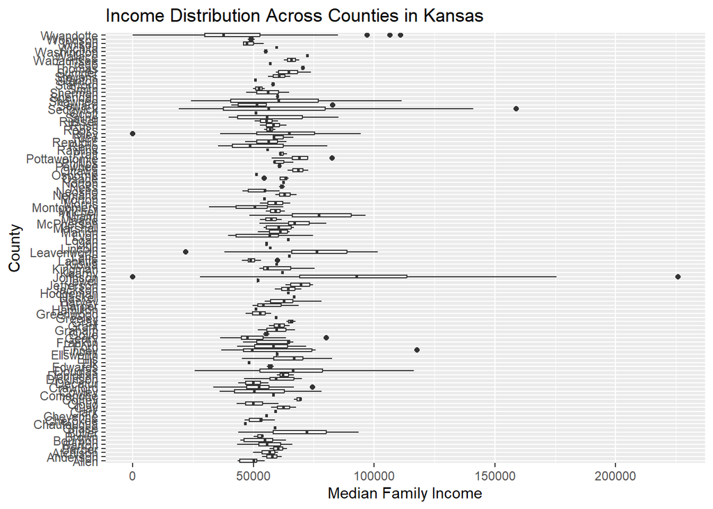

```r
# Using ggplot2 to draw a boxplot.
ggplot(ks_data, aes(x = County, y = MedianFamilyIncome)) +
  geom_boxplot() +
  coord_flip() +
  labs(x = "County", y = "Median Family Income", title = "Income Distribution Across Counties in Kansas")
```

```r
# save the image to check detail
ggsave("4.income_distribution_plot.png", plot = last_plot(), width = 20, height = 16, dpi = 300)
```

## From the boxplot image, we can find Johnson own the greatest variation in income.

## Are there significant differences across counties?

Answer：1.Variation in Median Income: The middle of boxplot means the median income, and different income exists in counties. Some of them are high, others are low.

Answer：2.Variation in Interquartile Range: The boxes dedicate the interquartile range, as well as the middle 50% of incomes. There are huge differences in the interquartile range across difference counties, meaning differences in income distribution.

```r
# Calculate the range of Median Family Income
county_variation <- aggregate(MedianFamilyIncome ~ County, data = ks_data, FUN = function(x) var(x, na.rm = TRUE))

# Find the the greatest variation in income to double check the viewpoint.
county_max_variation <- county_variation[which.max(county_variation$MedianFamilyIncome), ]

## Which counties have the greatest variation in income?
print(paste("Answer：County with the greatest variation in income:", county_max_variation$County))
```

```
## [1] "Answer：County with the greatest variation in income: Johnson"
```

## 5. How compares across locations with low (or not) food accessibility ().

```r
# Compare using both basic descriptive statistics and graphical representation
summary(ks_data$MedianFamilyIncome[ks_data$LAhalfand10 == 1])
```

```
##    Min. 1st Qu.  Median    Mean 3rd Qu.    Max.
##       0   46668   59107   63992   72816  225739
```

```r
summary(ks_data$MedianFamilyIncome[ks_data$LAhalfand10 == 0])
```

```
##    Min. 1st Qu.  Median    Mean 3rd Qu.    Max.
##       0   50805   63125   62653   75815  117703
```

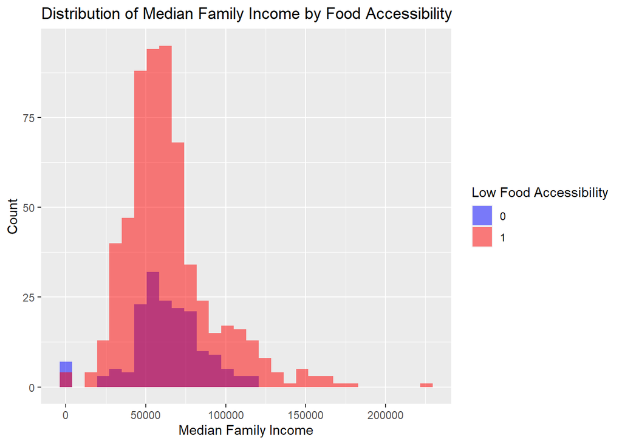

```r
# Using ggplot2 to compare
ggplot(ks_data, aes(x = MedianFamilyIncome, fill = factor(LAhalfand10))) +
  geom_histogram(position = "identity", alpha = 0.5, bins = 30) +
  labs(x = "Median Family Income", y = "Count", fill = "Low Food Accessibility") +
  ggtitle("Distribution of Median Family Income by Food Accessibility") +
  scale_fill_manual(values = c("blue", "red"))
```

## Summary Statistics:

- For areas with low food accessibility:
1. Minimum Median Family Income: 0
2. Maximum Median Family Income: 225,739
3. Median Median Family Income: $59,107
4. Mean Median Family Income: $63,992
- For areas with better food
1. Minimum Median Family Income: 0
2. Maximum Median Family Income: 117,703
3. Median Median Family Income: $63,125
4. Mean Median Family Income: $62,653

## 6. Using other variable to compare between counties with TractKids

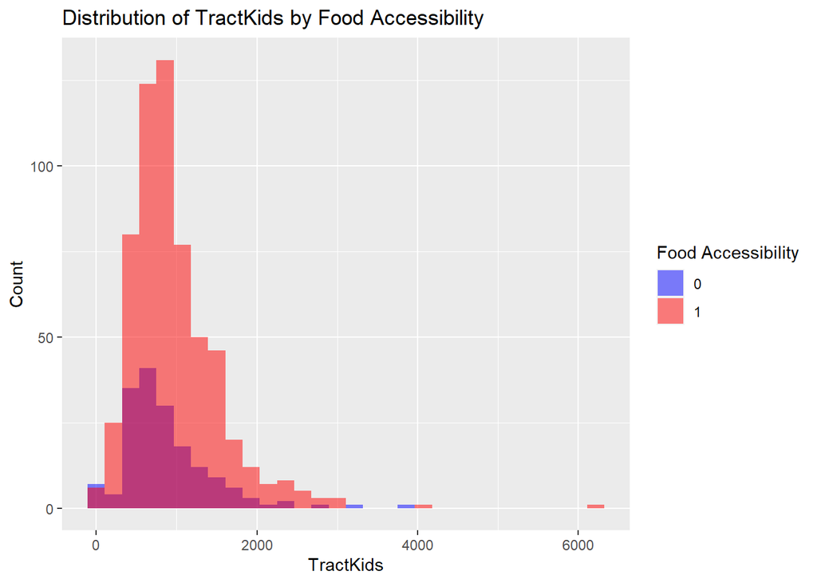

```r
# Compare using both basic descriptive statistics and graphical representation
summary_median_income_low_access <- summary(ks_data$MedianFamilyIncome[ks_data$LAhalfand10 == 1])
summary_median_income_regular_access <- summary(ks_data$MedianFamilyIncome[ks_data$LAhalfand10 == 0])

# Using ggplot2 to compare TractKids
ggplot(ks_data, aes(x = TractKids, fill = factor(LAhalfand10))) +
  geom_histogram(position = "identity", alpha = 0.5, bins = 30) +
  labs(x = "TractKids", y = "Count", fill = "Food Accessibility") +
  ggtitle("Distribution of TractKids by Food Accessibility") +
  scale_fill_manual(values = c("blue", "red"))
```

```r
summary_median_income_low_access
```

```
##    Min. 1st Qu.  Median    Mean 3rd Qu.    Max.
##       0   46668   59107   63992   72816  225739
```

```r
summary_median_income_regular_access
```

```
##    Min. 1st Qu.  Median    Mean 3rd Qu.    Max.
##       0   50805   63125   62653   75815  117703
```

## Summary Statistics:

- For areas with low food accessibility (LAhalfand10 == 1):
1. Minimum Median Family Income: $0
2. Median Median Family Income: $59,107
3. Mean Median Family Income: $63,992
4. Maximum Median Family Income: $225,739
- For areas with regular food accessibility (LAhalfand10 == 0):
1. Minimum Median Family Income: $0
2. Median Median Family Income: $63,125
3. Mean Median Family Income: $62,653
4. Maximum Median Family Income: $117,703

## 7. Explanation of Kansas dataset relate to food accessibility and food assistance (SNAP).

```r
# Compare using both basic descriptive statistics and graphical representation
summary(ks_data$TractSNAP[ks_data$LAhalfand10 == 1])
```

```
##    Min. 1st Qu.  Median    Mean 3rd Qu.    Max.
##     0.0    53.0   113.0   146.4   215.0   686.0
```

```r
summary(ks_data$TractSNAP[ks_data$LAhalfand10 == 0])
```

```
##    Min. 1st Qu.  Median    Mean 3rd Qu.    Max.
##     0.0    52.0    93.0   109.3   143.5   509.0
```

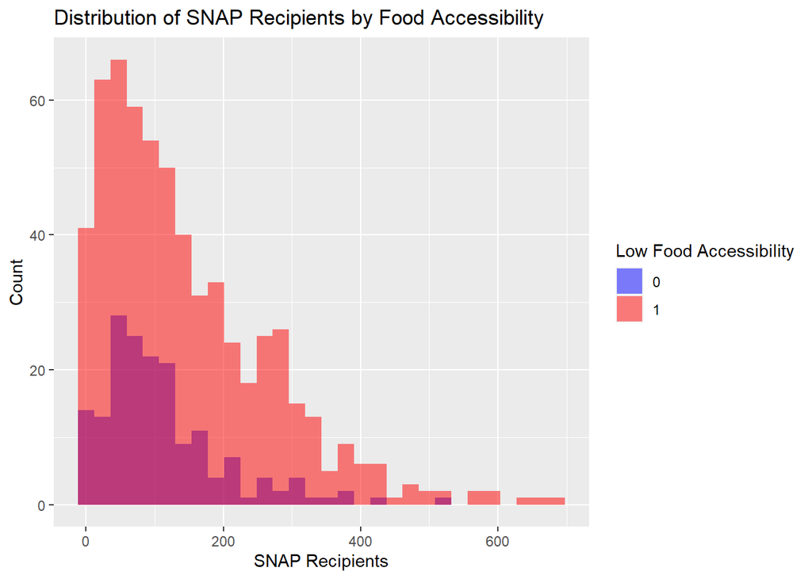

```r
# Using ggplot2 to compare
ggplot(ks_data, aes(x = TractSNAP, fill = factor(LAhalfand10))) +
  geom_histogram(position = "identity", alpha = 0.5, bins = 30) +
  labs(x = "SNAP Recipients", y = "Count", fill = "Low Food Accessibility") +
  ggtitle("Distribution of SNAP Recipients by Food Accessibility") +
  scale_fill_manual(values = c("blue", "red"))
```

## Summary Statistics:

- For areas with low food accessibility (LAhalfand10 == 1):
1. Minimum number of SNAP recipients: 0
2. Maximum number of SNAP recipients: 686
3. Median number of SNAP recipients: 113
4. Mean number of SNAP recipients: 146.4
- For areas with regular food accessibility (LAhalfand10 == 0):
1. Minimum number of SNAP recipients: 0
2. Maximum number of SNAP recipients: 509
3. Median number of SNAP recipients: 93
4. Mean number of SNAP recipients: 109.3

## Summary histogram:

- Obviouly, the count of LAhalfand10 == 1 is higher then LAhalfand10 == 0 significantly. Secondly, most distribution concentrate in 0-400.

## 8. Use reduced_data created in step 1 and create a state-by-state summary of each variable.

```r
# Grouping data by State
state_summary <- reduced_data %>%
  group_by(State) %>%
  summarize(
    Mean_Population = mean(POP2010),
    Mean_Occupied_Housing_Units = mean(OHU2010),
    Mean_Poverty_Rate = mean(PovertyRate),
    Median_Family_Income = median(MedianFamilyIncome),
    Mean_LowIncome_Tracts = mean(LowIncomeTracts),
    Mean_Low_Access_1And10 = mean(LA1and10),
    Mean_Low_Access_halfAnd10 = mean(LAhalfand10),
    Mean_Low_Access_1And20 = mean(LA1and20),
    Mean_Low_Access_Tracts_Half = mean(LATracts_half),
    Mean_Low_Access_Tracts_1 = mean(LATracts1),
    Mean_Low_Access_Tracts_10 = mean(LATracts10),
    Mean_Low_Access_Tracts_20 = mean(LATracts20),
    Mean_Households_With_No_Vehicle = mean(HUNVFlag),
    Mean_Snap_Participation = mean(TractSNAP)
  )

# Identify states with the highest and lowest food accessibility problems
highest_problems <- state_summary %>%
  arrange(desc(Mean_LowIncome_Tracts)) %>%
  head(5)

lowest_problems <- state_summary %>%
  arrange(Mean_LowIncome_Tracts) %>%
  head(5)

# Print results
cat("States with the most problems with food accessibility:\n")
```

```
## States with the most problems with food accessibility:
```

```r
print(highest_problems)
```

```
## # A tibble: 5 × 15
##   State                Mean_Population Mean_Occupied_Housing…¹ Mean_Poverty_Rate
##   <chr>                          <dbl>                   <dbl>             <dbl>
## 1 Mississippi                    4482.                   1685.              24.6
## 2 District of Columbia           3362.                   1490.              19.7
## 3 Alabama                        4054.                   1598.              21.2
## 4 Georgia                        4930.                   1825.              20.5
## 5 Louisiana                      3966.                   1512.              21.6
## # ℹ abbreviated name: ¹Mean_Occupied_Housing_Units
## # ℹ 11 more variables: Median_Family_Income <dbl>, Mean_LowIncome_Tracts <dbl>,
## #   Mean_Low_Access_1And10 <dbl>, Mean_Low_Access_halfAnd10 <dbl>,
## #   Mean_Low_Access_1And20 <dbl>, Mean_Low_Access_Tracts_Half <dbl>,
## #   Mean_Low_Access_Tracts_1 <dbl>, Mean_Low_Access_Tracts_10 <dbl>,
## #   Mean_Low_Access_Tracts_20 <dbl>, Mean_Households_With_No_Vehicle <dbl>,
## #   Mean_Snap_Participation <dbl>
```

```r
cat("\nStates with the lowest problems with food accessibility:\n")
```

```
##
## States with the lowest problems with food accessibility:
```

```r
print(lowest_problems)
```

```
## # A tibble: 5 × 15
##   State        Mean_Population Mean_Occupied_Housing_Units Mean_Poverty_Rate
##   <chr>                  <dbl>                       <dbl>             <dbl>
## 1 North Dakota           3281.                       1372.              12.1
## 2 Wyoming                4270.                       1719.              12.3
## 3 Vermont                3401.                       1394.              12.4
## 4 South Dakota           3667.                       1452.              14.9
## 5 Iowa                   3693.                       1481.              13.3
## # ℹ 11 more variables: Median_Family_Income <dbl>, Mean_LowIncome_Tracts <dbl>,
## #   Mean_Low_Access_1And10 <dbl>, Mean_Low_Access_halfAnd10 <dbl>,
## #   Mean_Low_Access_1And20 <dbl>, Mean_Low_Access_Tracts_Half <dbl>,
## #   Mean_Low_Access_Tracts_1 <dbl>, Mean_Low_Access_Tracts_10 <dbl>,
## #   Mean_Low_Access_Tracts_20 <dbl>, Mean_Households_With_No_Vehicle <dbl>,
## #   Mean_Snap_Participation <dbl>
```

## 9. Examine the trends between 3 variables of your choice and food accessibility across states in the US and describe your findings.

Following plot would focus on PovertyRate, MedianFamilyIncome, and HUNVFlag.

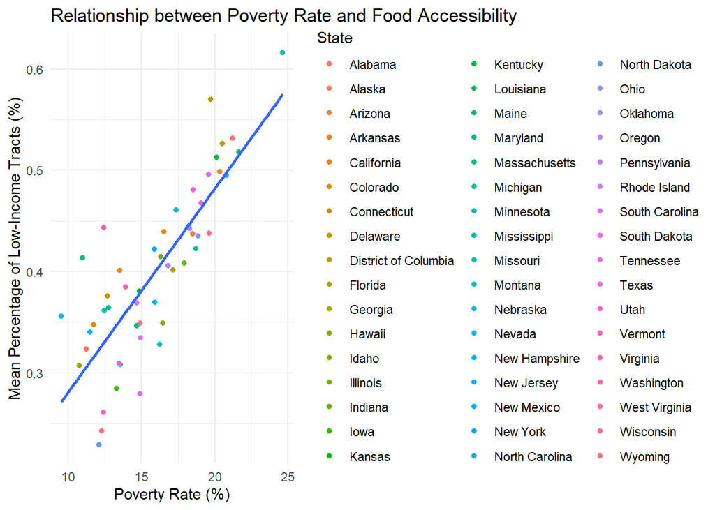

```r
# Scatterplot matrix to examine relationships
scatterplot_matrix <- ggplot(state_summary, aes(x = Mean_Poverty_Rate, y = Mean_LowIncome_Tracts)) +
  geom_point(aes(color = State)) +
  geom_smooth(method = "lm", se = FALSE) +
  labs(title = "Relationship between Poverty Rate and Food Accessibility",
       x = "Poverty Rate (%)",
       y = "Mean Percentage of Low-Income Tracts (%)") +
  theme_minimal()

scatterplot_matrix
```

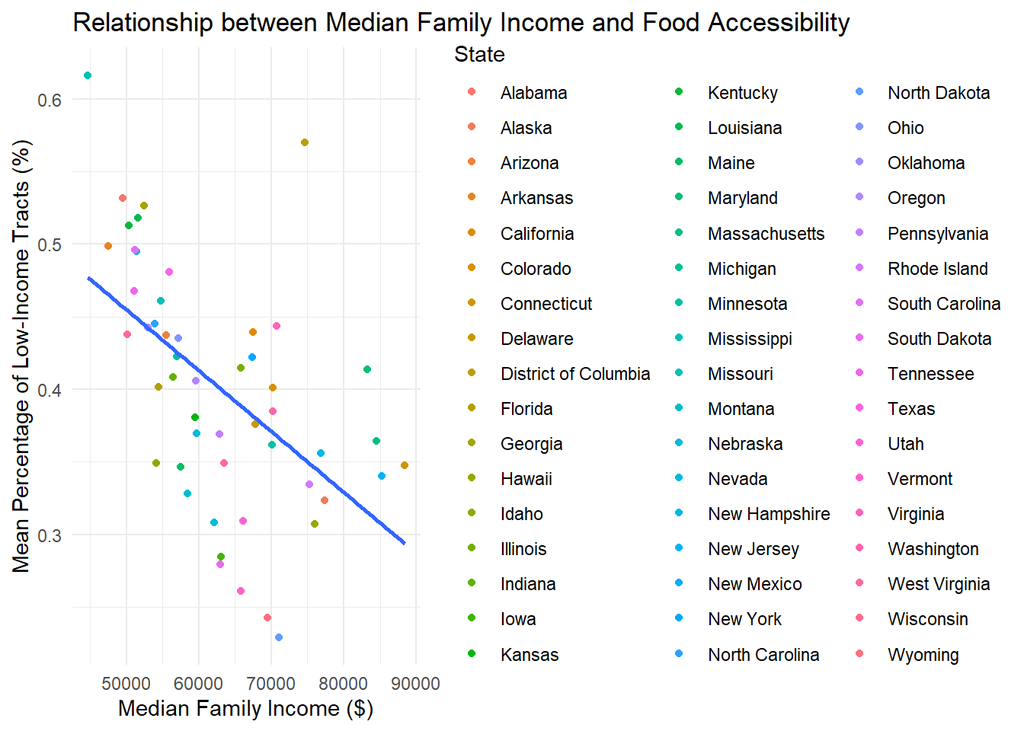

```r
# Scatterplot matrix for Median Family Income vs. Food Accessibility
scatterplot_matrix_income <- ggplot(state_summary, aes(x = Median_Family_Income, y = Mean_LowIncome_Tracts)) +
  geom_point(aes(color = State)) +
  geom_smooth(method = "lm", se = FALSE) +
  labs(title = "Relationship between Median Family Income and Food Accessibility",
       x = "Median Family Income ($)",
       y = "Mean Percentage of Low-Income Tracts (%)") +
  theme_minimal()

scatterplot_matrix_income
```

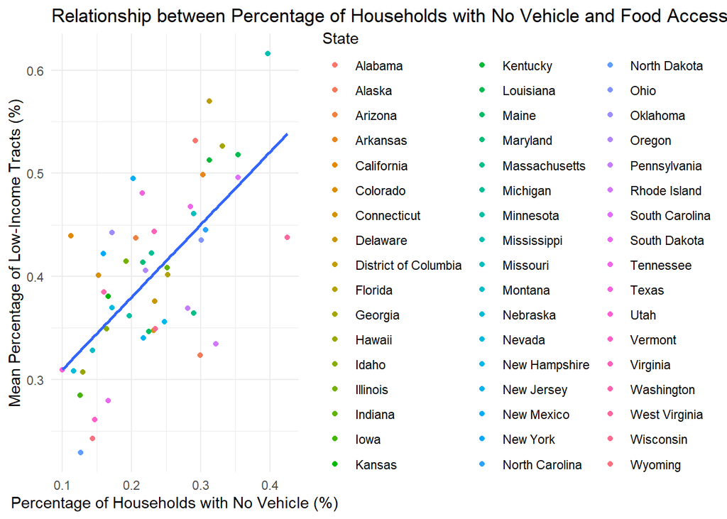

```r
# Scatterplot matrix for Percentage of households with no vehicle vs. Food Accessibility
scatterplot_matrix_vehicle <- ggplot(state_summary, aes(x = Mean_Households_With_No_Vehicle, y = Mean_LowIncome_Tracts)) +
  geom_point(aes(color = State)) +
  geom_smooth(method = "lm", se = FALSE) +
  labs(title = "Relationship between Percentage of Households with No Vehicle and Food Accessibility",
       x = "Percentage of Households with No Vehicle (%)",
       y = "Mean Percentage of Low-Income Tracts (%)") +
  theme_minimal()

scatterplot_matrix_vehicle
```

1. The first scatterplot matrix shows the relationship between poverty rate and food accessibility. It seems there’s a positive correlation, indicating that states with higher poverty rates tend to have a higher percentage of low-income tracts, suggesting poorer food accessibility.
2. The second scatterplot matrix explores the relationship between median family income and food accessibility. There appears to be a negative correlation, implying that states with higher median family incomes tend to have a lower percentage of low-income tracts and potentially better food accessibility. But! This regression is not strong relative as first scatterplot. There are more states be away from the regression line.
3. The third scatterplot matrix investigates the relationship between the percentage of households with no vehicle and food accessibility. It shows a positive correlation, suggesting that states with a higher percentage of households with no vehicle may experience challenges with food accessibility, potentially due to transportation limitations. However, the correlation is weakest.

## In this comparative analysis involving three variables—PovertyRate, MedianFamilyIncome, and HUNVFlag—it is evident that the regression line generated by PovertyRate exhibits the tightest clustering of data points. Following this, MedianFamilyIncome shows a moderate level of dispersion, while HUNVFlag displays the least concentration of data points, indicating the weakest correlation.

# Hence, among the three variables, Mean PovertyRate emerges as the most influential factor affecting the Percentage of Low-Income Tracts.